# Análisis Exploratorio y Estadístico de los Datos

2022-06-30

## **Estructura del trabajo exploratorio y estadístico**

**1)** **Introducción**

- Descripción de la problemática.

**2)** **Análisis exploratorio de los datos**

- Histogramas biomasa muerta (toneladas) por causa.
- Boxplot biomasa muerta por causa para los últimos 10 años.

**3)** **Análisis estadísitico de los datos**

- Modelos lineales simples y múltiple.
- Comparación de modelos RSS-AIC.

**4)** **Interpretación y conclusiones del trabajo**

## **Introducción**

**1).** **Descripción de la problemática**

- Base de datos presenta registros de mortalidad por causa **bloom de algas y disminución de oxígeno disuelto (OD)**.
- 23 centros de cultivos reportaron la causal de mortalidad en salmón para un barrio de la Región de Los Lagos.
- *Salmo salar* es la especie más cultivada en este barrio.

**2).** **Variables de estudio y número de observaciones**

- Los registros corresponden a reportes de mortalidad entre los años 2011 e incio del 2022 (Total de registros= 1224).
- Variables de estudio: Causa, peso (g), años, mes, semana e identificación de centro de cultivo.

## **Objetivos del estudio**

- Evaluar la causa de mortalidad por bloom de algas y OD sobre la especie *Salmo salar* para un barrio del sur de Chile entre los años 2011 a inicios del 2022.
- Generar un modelo lineal que mejor ajuste la predicción de mortalidad en la biomasa de salmones.

## **Análisis exploratorio de los datos**

- Datos desbalanceados por causa de muertes debido a bloom de algas (n= 360) y OD (n= 864).
- Año 2021 presentó una mayor biomasa muerta entre el 2011 al 2022.
- No existe correlación significativa (p<0.05) entre las causas de muerte por bloom de algas y disminución de oxígeno disuelto.
- Entre los periodos 2011 a 2022 existe una mayor biomasa muerta (ton) de *S. salar* en el barrio por causa de la acción de bloom de algas.

## **HISTOGRAMA**

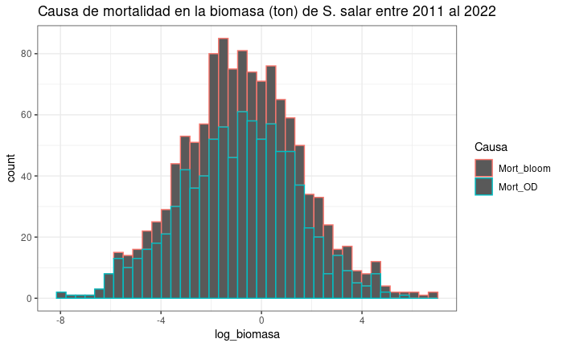

Histograma biomasa muerta (toneladas) por causa

## **Datos faltantes y datos atípicos: Boxplot**

- Boxplot consideró la causa de muerte sobre la biomasa de peces entre el 2011 al 2022.
- Datos faltantes para la causa de mortalidad por bloom entre el periodo 2011 a 2022.
- Valores atípicos presente en las dos causas de mortalidad.

## **BOXPLOT**

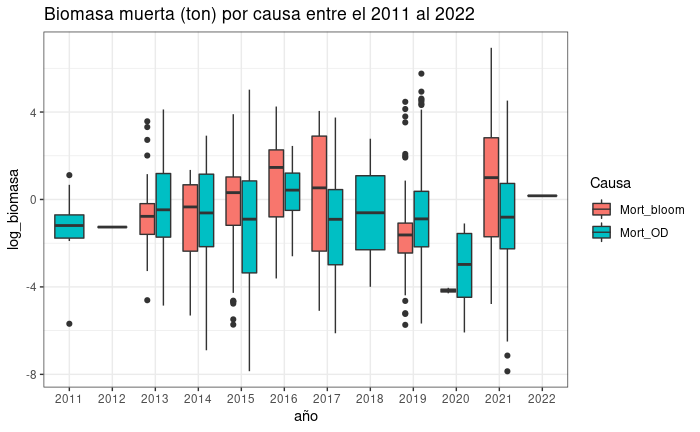

Boxplot biomasa muerta por año y causa

## **Análisis exploratorio de los datos: Plot**

- Se evidencia sobre la ocurrencia de un evento temporal puntual que generó una alta mortalidad en la biomasa de salmones.
- Año 2021 presentó la mayor biomasa de salmones muertos siendo afectada por la **acción de bloom de algas**.
- Año 2021 presentó la mayor mortalidad registrada históricamente en este barrio (log biomasa muerta > 5).

## **Relación biomasa muerta y las semanas que se reportó mortalidad**

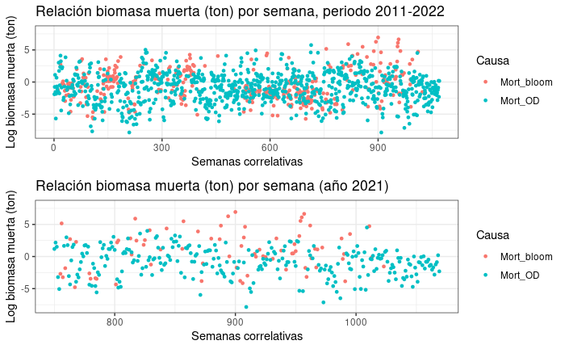

Biomasa muerta por semana y causa

## **Tabla resumen de la biomasa muerta por causa**

| Causa | N | Promedio | DE | Mediana | Mín | Máx |
| --- | --- | --- | --- | --- | --- | --- |
| Mort_bloom | 360 | 16.184949 | 82.38176 | 0.4478442 | 0.0032292 | 1031.4452 |
| Mort_OD | 864 | 4.071008 | 16.81336 | 0.4349179 | 0.0003860 | 316.1441 |

## **Análisis estadísitico de los datos: Modelo lineal simple**

- **Modelo de regresión lineal simple** con los factores centro, semanas y años.
- Modelos de regresión lineal simple con los factores fueron estadísticamente significativos (p < 0.05), pero con un bajo ajuste o R^2 ajustado menor al 7%.

## **Hipótesis modelo lineal simple**

- Basado en estos modelos de regresión simple se rechaza hipótesis nula que postulaba:

**Hipótesis nula (H0)**: Existe similitud en la biomasa muerta entre centros/semanas/años.

**Hipótesis alternativa (H1)**: No existe similitud en la biomasa muerta entre centros/semanas/años.

## **Hipótesis modelo lineal múltiple**

- El modelo cumplió con los tres supuestos: linealidad, homogeneidad de varianza y normalidad.

## **Análisis estadísitico de los datos: Ajuste modelo lineal múltiple**

- La modelación integró los factores causa, centro, año, mes y la inetracción entre causa y año.
- Modelo nos estrega como resultado coeficientes distintos de cero, por lo tanto, se rechaza la HO (valores p menores al 5%).
- El R^2 ajustado de esta modelación múltiple correspondió al 23%.

## **Análisis de varianza (ANOVA)**

|  | Df | Sum Sq | Mean Sq | F value | Pr(>F) |
| --- | --- | --- | --- | --- | --- |
| Causa | 1 | 63.15504 | 63.155039 | 14.624314 | 0.0001381 |
| año | 11 | 248.97448 | 22.634044 | 5.241187 | 0.0000000 |
| centro_id | 22 | 615.45852 | 27.975387 | 6.478040 | 0.0000000 |
| mes | 11 | 665.02969 | 60.457244 | 13.999607 | 0.0000000 |
| Causa:año | 7 | 175.41762 | 25.059660 | 5.802868 | 0.0000012 |
| Residuals | 1171 | 5056.95851 | 4.318496 | NA | NA |

## **Interpretación y y conclusiones del trabajo**

- Análisis exploratorio muestra mayor mortalidad de la biomasa de peces en el barrio por bloom.
- Mortalidad por baja de OD presenta mayor frecuencia.
- Se realizó ANOVA con un vía de criterio de clasificación para los factores centro de cultivo, semanas y años con ajustes menores al 7%.